# Master en Data Science I

## PALABRAS, FUENTES y ALGO MÁS

```r
tmp2 <- pdf.metadata[,c("TIPO","TWORDS1","FONTS","PAGELINESFIRST","PAGELINESLAST")]

g.words1 <- ggplot(tmp2, aes(TWORDS1, fill = TIPO, colour = TIPO)) +
              geom_density(alpha = 0.6) +  ggtitle("Palabras en 1ª pág.") +
              theme(axis.title.x=element_blank()) + xlim(1,100)

g.fonts <- ggplot(tmp2, aes(FONTS, fill = TIPO, colour = TIPO)) +
              geom_density(alpha = 0.6) +  ggtitle("Fuentes incrustadas") +
              theme(axis.title.x=element_blank()) +  xlim(1,100)

g.pgl1 <- ggplot(tmp2, aes(PAGELINESFIRST, fill = TIPO, colour = TIPO)) +
              geom_density(alpha = 0.6) +  ggtitle("Líneas en 1ª pág.") +
              theme(axis.title.x=element_blank()) + xlim(1,100)

g.pglast <- ggplot(tmp2, aes(PAGELINESLAST, fill = TIPO, colour = TIPO)) +
              geom_density(alpha = 0.6) +  ggtitle("Líneas en última pág.") +
              theme(axis.title.x=element_blank()) +  xlim(1,100)
```

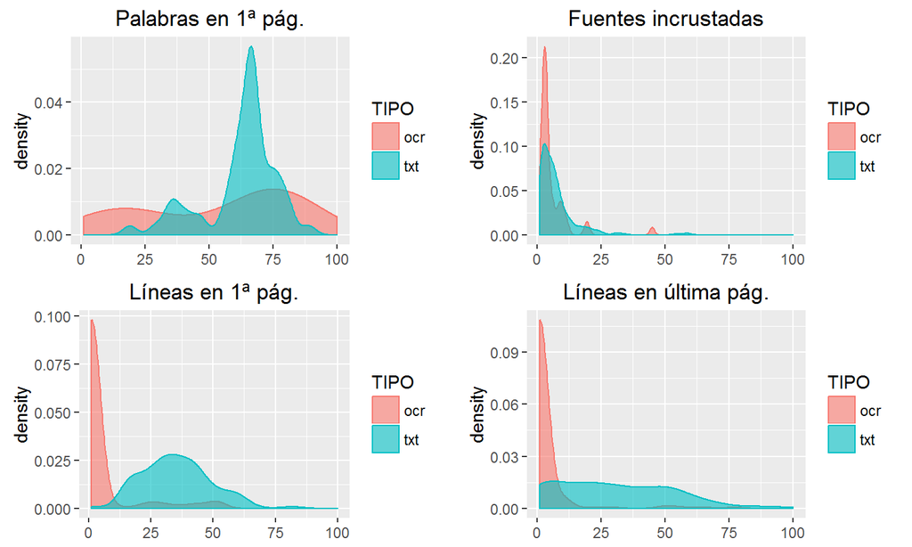

```r
grid.arrange(g.words1, g.fonts, g.pgl1, g.pglast, ncol=2, nrow =2)
```

## ÁRBOL DE CLASIFICACIÓN

```r
library(party)

tmp3 <- pdf.metadata[, !(colnames(pdf.metadata) %in% ("FILE"))]

arbol.ct <- ctree(TIPO ~ IMAGES+ROTATION+PAGELINESSECOND+FWORDS1+TWORDS1+FONTS+PAGES+SIZE, data = tmp3)

reales.ct <- tmp3$TIPO

predichos.ct<- predict(arbol.ct)

confusion <- table(reales.ct, predichos.ct)
```

```r
kable(confusion, format="html")
```

|  | ocr | txt |
| --- | --- | --- |
| ocr | 225 | 31 |
| txt | 5 | 259 |

**En términos generales se confirman las sospechas. Los documentos para OCR tienen pocas fuentes incrustadas, pocas palabras, muchas imágenes y no poseen los 3 vocablos más frecuentes del Español en su primera página.** Sin embargo, deberá tenerse en cuenta que algunos de ellos son calificados como texto (ver matriz de confusión)

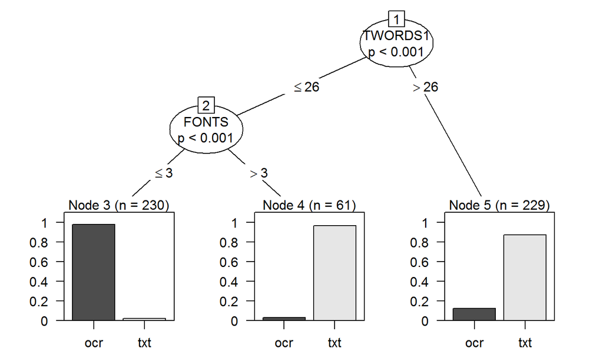

```r
plot(arbol.ct, tp_args = list(beside = TRUE))
```

## PUNTO DE CORTE

Sabido lo anterior, se define en el bash script **extraccion.sh** (líneas 310 a 364) la clasificación preliminar de los documentos con una mezcla de sentido común y de los indicios del árbol de la siguiente forma:

- Más de 20 páginas obliga a lectura (requisito de negocio). Se mueve a directorio *rejected*
- Fuentes incrustadas menor o igual a 1: se mueve a directorio *pdf_ocr*
- Menos de 3 en el conteo de 3 palabras más frecuentes en Español según RAE: a directorio *pdf_ocr*
- Más imágenes que páginas: se mueve a directorio *pdf_ocr*
- Más de 20 líneas de texto en primera página : se mueve a directorio *pdf_txt*

Como aún así es posible que algún PDF quede sin procesar, en las líneas 22-46 del script *code/resumen_juridico.sh* se comprueba que todos los textos extraidos tengan contenido.

En tal caso se guarda el nombre del archivo en un log y se mueve a la carpeta *non processed* para revisión posterior al finalizar la ejecución del proceso. Puede ser interesante investigar qué tipo de archivos escapan a la conversión.

Gestión de ficheros vacíos:

```r
#!/bin/bash
if [ "$en_documento" == 0 ];then

nombrepdf=$(basename $f .txt)".pdf"
nombresinext=$(basename $f .txt)

mv $f ../non_processed/

        if [ -f ${OUTPUT}"/pdf_ocr/"${nombrepdf} ]; then  # si estaba clasificado como OCR
          mv "$OUTPUT/pdf_ocr/"${nombrepdf}  ../non_processed/
        fi

        if [ -f ${OUTPUT}"/pdf_txt/"${nombrepdf} ]; then  # si estaba clasificado como TXT
          mv "$OUTPUT/pdf_txt/"${nombrepdf}  ../non_processed/
        fi

            echo $f >> ${OUTPUT}"/error.log"
fi
```

Una vez clasificados los PDF como "txt" o como "ocr" se pasa a extraer el contenido mediante *pdftotext* en el primer caso, y usando una combinación de *convert* (extrae las imágenes) y *tesseract* (realiza el OCR) en el segundo. En pruebas iniciales este proceso se revela extremadamente lento. Por ello con GNU Parallel lanzamos un hilo por cada nucleo del procesador (parámetro obligatorio **THREADS**).

Ejemplo de extracción de contenido en pdf compuesto por texto

```r
#!/bin/bash

pdftotext -enc UTF-8  "$pdf_file" ${OUTPUT}/processed/${FILENAMEsinPDF}.txt
```

Ejemplo de extracción multihilo en pdf compuesto por imágenes escaneadas (GNU Parallel)

```r
#!/bin/bash

# convert (extrae imágenes del PDF)
find . -name '*.pdf' | parallel -j ${THREADS} --progress convert -density 600 -trim {} \
-quality 100 -set filename:f '%t'  '../tmp/$(basename '{}' .pdf)'__%03d.jpg

# tesseract (ocr a los jpg extraidos)
find . -name '*.jpg' | parallel -j ${THREADS} --progress tesseract {} -l spa '$(basename '{}' .jpg)'
```

Se obtiene como resultado del anterior proceso:

- Una imagen por cada página del documento.
- Un fichero de texto plano con el contenido interpretado mediante OCR por cada imágen del paso anterior.

Ahora se debe por tanto concatenar cada uno de los ficheros de texto en el mismo orden en que se lee en el PDF original.

Concatenado de los ficheros de texto con nombre del PDF original:

```r
#!/bin/bash

for tt in "../tmp/"$(echo $nombrebase | sed -e 's/]/?/g')   # para cada fichero de texto
do
  FINALTXTNAME=$(echo ${nombrebase} | sed -e 's/\*//g')  # capturamos nombre de PDF "padre"

    cat $tt | sed 's/\o14//g' | tr -cd '\11\12\15\40-\176' | sed '1 s/\xEF\xBB\xBF//'  \
    | sed '/^$/d' | sed 's/[^[:print:]]/ /g' | sed 's/-//g' | sed 's/_\._//g'       \
    | sed 's/"//g' | sed 's/_\.//g' | sed 's/"//g' | sed "s/'//g"             \
    >> ${OUTPUT}"/processed/"${FINALTXTNAME}

                rm -f $tt  # borramos todos los textos "hijo"
done
```

## PÉRDIDA DE INFORMACIÓN

Es esperable cierto grado de pérdida de información en el proceso OCR. Máxime cuando los archivos de origen son malas copias de un original, tienen tachaduras o escrituras a mano, imágenes torcidas, etc.

Para poder tener alguna idea de esta magnitud, se extrae un valor numérico de la pérdida sufrida, pasando el texto resultante por un diccionario (*aspell_es*) y computando el número de palabras que no se hallan en él.

Es una estimación muy burda, pues cosas como los nombres propios no se encontrarán, pero sirve al propósito de informar del ratio de pérdida de manera consistente para todos los documentos.

\(perdida=\frac{total NO encontradas en diccionario}{total palabras en documento}\)

```r
#!/bin/bash
for t in *.txt
do
  en_documento=$(cat "$t" | wc -w)     # contamos el total de palabras
    no_en_dicc=$(cat "$t" | aspell list | sort -u -f | wc -l) # aspell
    perdida=$(echo "scale=2;$no_en_dicc / $en_documento" |bc -l) # ratio calculado
    echo "$t tiene una pérdida de $perdida"
done
```

## EXTRACCIÓN DE PALABRAS ESCOGIDAS

Cada departamento saca conclusiones y toma decisiones en base al contenido de cada pdf.

En reuniones mantenidas a tal efecto, se recoge una lista de palabras clave que, según su experiencia, les ayuda a clasificar y decidir la importancia de cada documento.

Esta lista de palabras se incorpora a un script separado por cada departamento que se cargará (o no) en función del parámetro obligatorio de entrada STYPE (lineas 465-469 del bash script **extraccion.sh**)

Este script realiza un parseo del texto por expresiones regulares, contabilizando tanto palabras sueltas como agrupadas, e incluso realizando una extracción tentativa de textos más complejos a un CSV.

**IMPORTANTE:**

*El citado script se aporta a modo de ejemplo aunque los textos a parsear se han sustituido por motivos de confidencialidad.*

## RESULTADOS PRELIMINARES

El resultado de este primer tramo, genera una serie de directorios con los documentos clasificados según el proceso sufrido, y un archivo csv donde se reflejan la pérdida de la conversión y el total de palabras de cada uno de ellos: data/accuracy.csv

Se muestran unas líneas:

| DOCUMENTO | PERDIDA | PALABRAS |
| --- | --- | --- |
| F001 | .22 | 211 |
| F002 | 1 | 0 |
| F003 | .13 | 212 |
| F004 | .17 | 60 |
| F005 | .04 | 168 |
| F006 | .05 | 212 |

## FEEDBACK

El feedbak de los diferentes departamentos es muy positivo, llevando procesados hasta el momento más de 25.000 documentos mediante este sistema desde la puesta en marcha.

Las mejoras en los tiempos son evidentes, pasando en el caso más exitoso, de una lectura/procesado promedio de 150 documentos a la semana, a más de 3.000 en el mismo periodo de tiempo.

Los usuarios solamente acuden al documento original cuando la pérdida de información en el proceso supera el 15%. Para todo lo demás, operan sobre el CSV que contiene los resultados, con verificaciones ocasionales que hasta el momento no han informado de problemas.

Tanto es así, que se han asignado más recursos materiales al proyecto, y el hardware inicial, bastante limitado por ser una prueba piloto, ha escalado verticalmente y se dispone ahora de 4 veces más capacidad de proceso, habiéndose reducido los tiempos de la fase de cómputo a una cuarta parte.

## CLASIFICACIÓN POR CONTENIDOS

## UNOS PASOS MÁS

Se aprovecha este éxito inicial, para intentar ir un paso más allá y realizar una clasificación por temas.

El primer problema encontrado es, que aquellos pdf de mala calidad, tras el OCR generan un archivo de texto con muchas palabras que no corresponde con palabras reales.

Algunas de esas palabras son comprensibles aunque serían rechazadas por un diccionario (procurador ~ procurad**e**r). Por desgracia, ni *aspell* ni otros sistemas probados ofrecen una corrección automática.

De modo que, esta vez se usa *aspell* para generar un listado completo de palabras no aceptadas, que posteriormente se revisarán para apreciar el éxito del OCR más allá del cálculo numérico de pérdida.

```r
#!/bin/bash
# volcar todas las palabras que no están en el diccionario a un archivo
 for file in *.txt
  do
  cat "$file" | tr '\n\r' ' ' | aspell list | sort -u -f >> base_stopwords.txt
  done

# Orden por frecuencias únicas descendentes y revisar
 cat base_stopwords.txt | sort | uniq -c | sort -nr > cleaning_stopwords.txt
```

## RESULTADO (muestra)

```r
#!/bin/bash
 cat stopwords.txt
    1249 ña
    1198 ENJ
    1188 Ia
    1165 ﬁ
    1156 Not
    1156 Hash
    1144 Pérez
    1120 Álvaro
    1112 OF
    1106 pdf
     992 II
     989 Io
     987 ei
     981 ll
     880 INST
```

## DECISIÓN

Se puede ver que las mayores frecuencias son artefactos del OCR o nombres propios. Por tanto se decide dejar los textos tal cual pero seleccionar para la clasificación aquellos con más de 5 líneas y un máximo del 15% de pérdida. Este proceso se ejecuta mediante el bash script ../code/cleaner.sh

```r
#!/bin/bash
 for f in *.txt
 do
lineas=""$(cat "$f" | wc -l)

if [ "$lineas" -gt 5 ]; then # más de 5 líneas

    # solamente letras, numeros,  espacios y separador de nueva linea
    limpio=""$(cat $f | tr -cd '[[:alnum:]][áéíóúÁÉÍÓÚñÑªºüÜ°;-]\040\012' | sed '/^$/d' )

    en_documento=$(echo "$limpio" | wc -w)     # total de palabras
    no_en_dicc=$(echo "$limpio" | aspell list | sort -u -f | wc -l) # aspell inverso
    perdida=$(echo "($no_en_dicc / $en_documento)*100" | bc -l) # ratio

    if (( $(echo "$perdida < 15"|bc -l) )) ;then
            echo "$limpio" > cleaned/$f
    fi
fi
done
```

## OBSERVACIONES

**Describiremos el proceso en términos generales y solamente se mostrarán datos cuando no se comprometan los acuerdos de confidencialidad.**

## DOCUMENT TERM MATRIX

```r
library(tm); library(stringi)

# lectura del directorio de documentos (no aportado). Resultado del script anterior.
files <- DirSource(directory = "../documentos/",encoding ="UTF-8" )
docs <- VCorpus(x=files)

# transformaciones aplicadas al corpus
docs <- tm_map(docs, content_transformer(removePunctuation))
docs <- tm_map(docs, content_transformer(tolower))
docs <- tm_map(docs, removeWords,c("maria","garcia","jose","julio","manuel","juan","martinez","alvaro","perez"))
docs <- tm_map(docs, removeWords, stopwords("spanish"))
docs <- tm_map(docs, content_transformer(removeNumbers))
# el proceso elimina la barra que separa géneros en la palabra abogado/a: se hace replace
docs <- tm_map(docs, content_transformer(function(x) stri_replace_all_fixed(x, "abogadoa",
                                                            "abogado", vectorize_all = FALSE)))
docs <- tm_map(docs, content_transformer(stripWhitespace))
# creación de la matriz DTM
dtm <- DocumentTermMatrix(docs)
dtm <- removeSparseTerms(dtm, 0.9)
# preservamos el contenido de la matriz en disco para uso posterior
matriz <- as.matrix(dtm)
dim(matriz)
df <- as.data.frame(matriz)
# dar nombre a la columna rownames
df <- cbind(FILENAMES = rownames(df), df)
# nos deshacemos de la original
rownames(df) <- NULL
write.csv(df, file="../data/df_dtm.csv", sep = ";")
```

## WORD CLOUDS (4 tipos de documento)

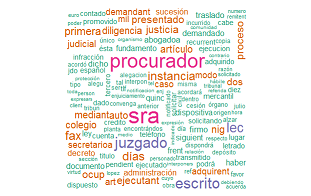

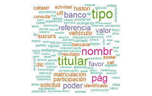

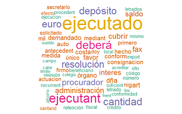

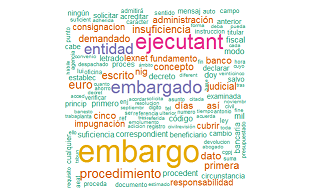

```r
# extraemos la nube de palabras de cada uno de los tipos de documento
library(wordcloud)
freq <- colSums(as.matrix(dtm))
set.seed(1234)
wordcloud(names(freq), freq, min.freq=10, random.order=FALSE, rot.per=.20, colors=brewer.pal(8, "Dark2"))
```

## TOPIC MODEL

```r
# generamos el topic model para el conjunto de todos los documentos mezclados
# asignamos al parámetro k el número de topics deseado (4)

library(topicmodels)
burnin <- 4000
iter <- 2000
thin <- 500
seed <-list(2003,5,63,100001,765)
nstart <- 5
best <- TRUE
k <- 4

freqs <- apply(dtm, 1, sum)
m     <- dtm[freqs > 0, ]
ldaOut <-LDA(m, k, method="Gibbs", control=list(nstart=nstart, seed = seed,
                                                best=best,burnin = burnin,
                                                iter = iter, thin=thin))
```

## TÉRMINOS MÁS FRECUENTES POR TEMA

```r
ldaOut@terms
Terms <- terms(ldaOut, 10)
```

```r
load("../data/temas.Rdata")
temas <- as.data.frame(temas)
```

```r
library(knitr)
kable(temas, format="html")
```

| Topic 1 | Topic 2 | Topic 3 | Topic 4 |
| --- | --- | --- | --- |
| bien | part | procurador | cuenta |
| embargo | sra | part | dato |
| ejecutado | present | juzgado | fecha |
| ejecutant | posición | ejecución | judici |
| sra | juicio | instancia | tipo |
| depósito | judici | fax | nombr |
| recurso | banco | primera | banco |
| entidad | plazo | notificación | saldo |
| mejora | secretario | procedimiento | código |
| deberá | procedimiento | justicia | general |

## CLUSTERS MEDIANTE KMEANS

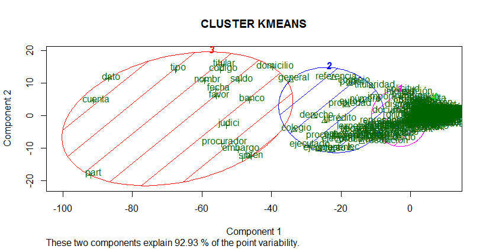

```r
library(fpc)
d <- dist(t(dtm), method="euclidian")
kfit <- kmeans(d, 4)
clusplot(as.matrix(d), kfit$cluster, color=T, shade=T, labels=2, lines=0, main="CLUSTER KMEANS" )
```

## PREDICCIÓN DE TEMAS

```r
library(party)

# carga del CSV con los contenidos de la DTM (disponible en carpeta data)
dtm.df <- read.csv("../data/df_dtm.csv", sep=";", stringsAsFactors=FALSE)

# Extraemos a un campo nuevo la etiqueta del tipo de documento
# está inserta en el nombre entre el guión bajo y la extensión

inicio <- regexpr('[_]',dtm.df$FILENAMES)+1
fin <- regexpr('[.]',dtm.df$FILENAMES)-1

dtm.df$LABEL <- substring(dtm.df$FILENAMES, inicio , fin)

table(dtm.df$LABEL)
```

```
##
##     APROBACION NOTIFICACIONES   ORDENAMIENTO          OTROS
##            294            140             58             28
```

## ÁRBOL DE TEMAS

```r
# descartar el nombre del archivo. Para clasificación NO es util
res <- dtm.df[, !(colnames(dtm.df) %in% ("FILENAMES"))]

res$LABEL<-as.factor(res$LABEL)

arbol.temas <- ctree(res$LABEL ~ ., data = res)

reales.temas <- res$LABEL
predichos.temas <- predict(arbol.temas)

temas.confusos <- table(reales.temas, predichos.temas)

kable(temas.confusos, format = "html")
```

|  | APROBACION | NOTIFICACIONES | ORDENAMIENTO | OTROS |
| --- | --- | --- | --- | --- |
| APROBACION | 289 | 0 | 2 | 3 |
| NOTIFICACIONES | 8 | 128 | 1 | 3 |
| ORDENAMIENTO | 8 | 2 | 48 | 0 |
| OTROS | 7 | 6 | 4 | 11 |

## PLOT ÁRBOL DE TEMAS

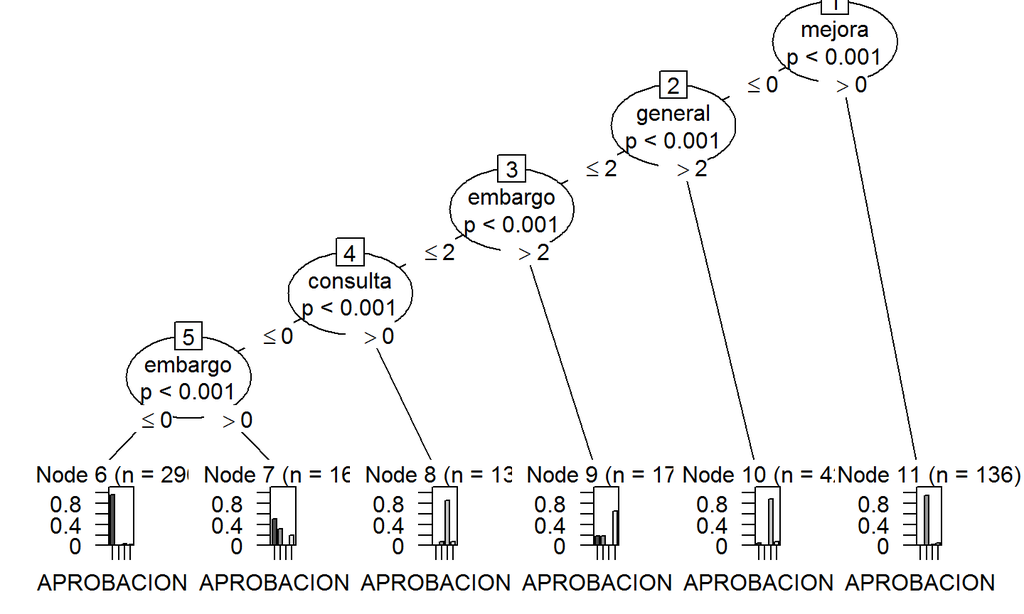

```r
plot(arbol.temas, tp_args = list(beside = TRUE)) # ATENCIÓN: por tamaño,no logra verse completo
```

```r
# se adjunta en alta resolución en la  carpeta ../plots/arbol_temas.png
```

## CLASIFICACIÓN A CSV

A partir de las indicaciones de este último árbol se implementa un script (*../code/clasificador.sh*) que vuelca a CSV (*../data/predicitivo_temas.csv*) la clasificación obtenida. Este CSV se ha entregado a los correspondientes departamentos para que cotejen su fiabilidad.

```r
#!/bin/bash
    contiene_mejora=""$(echo "$CONTENIDOF" | grep -E -i -o -c '\bmejora\b')
    contiene_general=""$(echo "$CONTENIDOF" | grep -E -i -o -c '\bgeneral\b')
    contiene_embargo=""$(echo "$CONTENIDOF" | grep -E -i -o -c '\bembargo\b')
    contiene_consulta=""$(echo "$CONTENIDOF" | grep -E -i -o -c '\bconsulta\b')
    tema_detectado="desconocido"

# clasificación por contenido extraída a partir de arbol de inferencia con R
if [ $contiene_mejora -gt 0 ]; then
        tema_detectado="NOTIFICACIONES"
    else
        if [ $contiene_general -gt 2 ]; then
          tema_detectado="ORDENAMIENTO"
        else
            if [ $contiene_embargo -gt 2 ]; then
                        tema_detectado="OTROS"
                else
                    if [ $contiene_consulta -gt 0 ]; then
                                tema_detectado="ORDENAMIENTO"
                            else
                                if [ $contiene_embargo -gt 0 ]; then
                                    tema_detectado="APROBACION-NOTIFICACIONES-OTROS"
                                else
                                tema_detectado="APROBACION"
                            fi
                            fi
                        fi
                    fi
            fi
```

```r
# carga del CSV con los contenidos del csv predictivo_temas (disponible en carpeta data)
predictivo.temas <- read.csv("../data/predictivo_temas.csv", sep="^", stringsAsFactors=FALSE)

# muestra de los contenidos
kable(head(predictivo.temas))
```

| DOCUMENTO | PREDICCION | MEJORA | GENERAL | EMBARGO | CONSULTA |
| --- | --- | --- | --- | --- | --- |
| F001 | APROBACION-NOTIFICACIONES-OTROS | 0 | 1 | 1 | 0 |
| F002 | APROBACION | 0 | 1 | 0 | 0 |
| F003 | NOTIFICACIONES | 3 | 2 | 5 | 0 |
| F004 | NOTIFICACIONES | 3 | 1 | 5 | 0 |
| F005 | APROBACION | 0 | 0 | 0 | 0 |
| F006 | APROBACION | 0 | 0 | 0 | 0 |

## MIENTRAS TANTO…

Mientras los departamentos correspondientes van evaluando la idoneidad de este modelo sencillo, se prosigue en la búsqueda del modelo predictivo más ajustado. Entre otras cosas, se ha mejorado la lectura de datos y la generación de modelos con las siguientes inclusiones:

1. Diferentes modos de generar las rutas según si la máquina es Linux o Windows
2. Comprobación previa de la existencia del objeto antes de generarlo

Para ello vamos a probar con diferentes modelos (En el archivo **modelos.R**)

- Ctree
- Evolutionary tree
- Knn
- Jacknife
- Random forest
- Naive-Bayes
- Support Vector Machine
- Gradient Boosting Machine

## CONCLUSIONES

## **Se ha logrado en gran medida el objetivo.**

Los procesos de lectura y clasificación se han acelerado mucho, principalmente en la primera fase de extracción de contenidos.

Tal y cómo hemos mencionado con anterioridad, se logran procesar más de 3.000 documentos a la semana cuando antes era habitual unos 150 en el mismo periodo de tiempo.

El número total de documentos procesados superó este mes los 26.000 dado que se ha solicitado incluso que se aplique esta metodología a antiguos proyectos

Los procesos de clasificación, por las noticias que tenemos, se han acelerado igualmente, aunque queda por evaluar la precisión del sistema predictivo, sustituir el árbol de decisión inicial por el modelo basado en knn y articular mecanismos de verificación en caso de ser necesario a partir de las indicaciones de cada uno de los departamentos.

```
                                        Jose Manuel Vera Oteo, en Madrid, a 9 de Junio de 2016
```